# Лабораторная работа № 14

Программирование в командном процессоре ОС UNIX. Расширенное программирование

Чжан Вэньцзюнь

Российский университет дружбы народов

РУДН

2026-10-20

# Информация

## Докладчик

- Чжан Вэньцзюнь
- зачётная книжка № 1132259051
- Российский университет дружбы народов им. П. Лумумбы

## Цель работы

- Изучить основы программирования в оболочке ОС UNIX
- Научиться писать сложные командные файлы
- Освоить логические конструкции, циклы и работу с ресурсами

## Задание

1. Упрощённый механизм семафоров (ожидание `t1`, использование `t2`, 3+ процесса)
2. Реализация команды `man` командным файлом (`/usr/share/man/man1`)
3. Генератор случайной последовательности латинских букв на `$RANDOM`

# Выполнение работы

## 1. Упрощённый семафор

```bash
while ! mkdir "$LOCK" 2>/dev/null; do
  echo "[$$] ресурс занят, жду $T1 с..."
  sleep "$T1"
done
echo "[$$] РЕСУРС ЗАХВАЧЕН, использую $T2 с"
sleep "$T2"
rmdir "$LOCK"
```

- `mkdir` — атомарная операция, служит замком
- `$$` — PID процесса, различает участников
- Поддерживается 3 и более процесса
- Вывод можно перенаправить в другой терминал: `> /dev/ttyN`

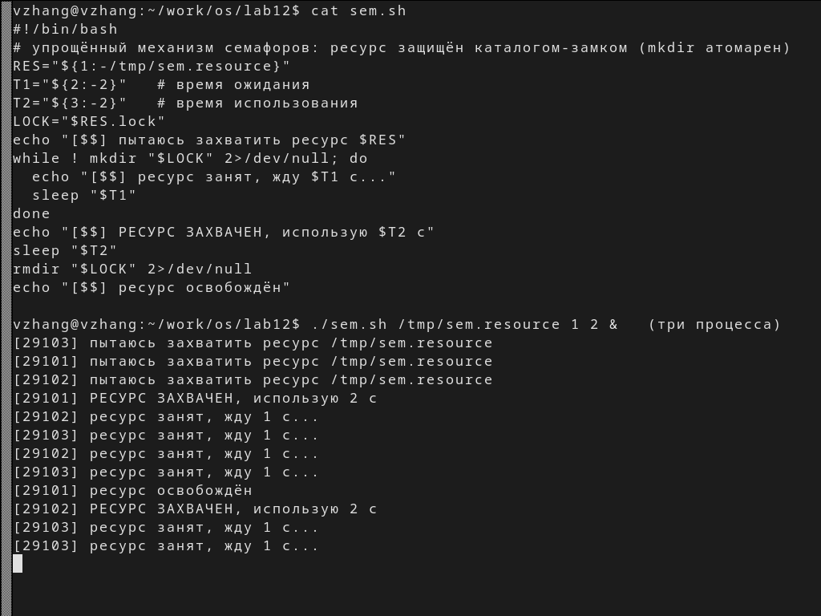

Три процесса и упрощённый семафор

## 2. Реализация команды man

```bash
for f in "$DIR/$CMD".1 "$DIR/$CMD".1.gz "$DIR/$CMD".1.xz; do
  [ -f "$f" ] || continue
  zcat "$f" | GROFF_NO_SGR=1 groff -man -Tutf8 | col -b
  exit 0
done
echo "Справка не найдена" >&2
exit 1
```

- Страницы в `/usr/share/man/man1` хранятся сжатыми (`.gz`)
- `zcat` + `groff -man -Tutf8` + `col -b` — форматирование
- Отсутствующая команда → сообщение и код возврата 1

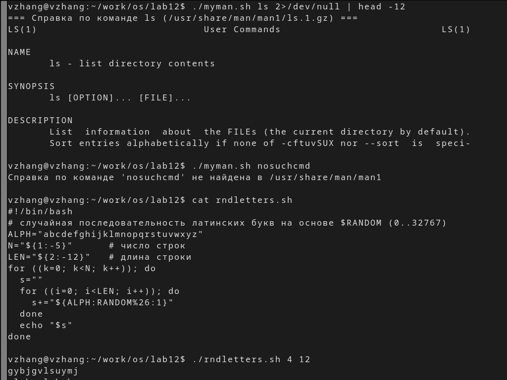

Работа myman.sh и rndletters.sh

## 3. Генератор случайных букв

```bash
ALPH="abcdefghijklmnopqrstuvwxyz"
for ((i=0; i<LEN; i++)); do
  s+="${ALPH:RANDOM%26:1}"
done
```

- `$RANDOM` — 0…32767
- `% 26` — индекс 0…25
- `${ALPH:index:1}` — выбор буквы
- Пример: `sbebqbqthgwf`

# Заключение

## Выводы

- Реализован семафор на атомарной операции `mkdir` для 3+ процессов
- Освоено перенаправление вывода в другой терминал (`/dev/ttyN`)
- Реализован аналог `man` с чтением сжатых страниц и `groff`
- Написан генератор случайных букв на `$RANDOM`
- Изучены циклы `while`, `for ((;;))` и подстановка параметров

## Спасибо за внимание!

Вопросы?